# Compulsory exercise 2: Group 27

TMA4268 Statistical Learning V2021

Maren Bråthen Kristoffersen, Vilde Marie Skårdal Jensen and Viveka Priya Simhan

13 april, 2021

### Problem 1

### a) Multiple choice 1

1. TRUE
2. TRUE
3. TRUE
4. FALSE

### b) Best subset selection

For this task, we will perform best subset selection to obtain a reduced linear regression model based on the `catdat` dataset. Below, we have used the function `regsubsets()`to implement the best subset selection method.

```r
numPred = 17
BSS = regsubsets(birds~., data = catdat.train, nvmax = numPred)
BSS_summary = summary(BSS)
```

By observing the graphs below, that are illustrating the optimal numbers of predictors for different criterions, we want to determine which model choice criterion to use.

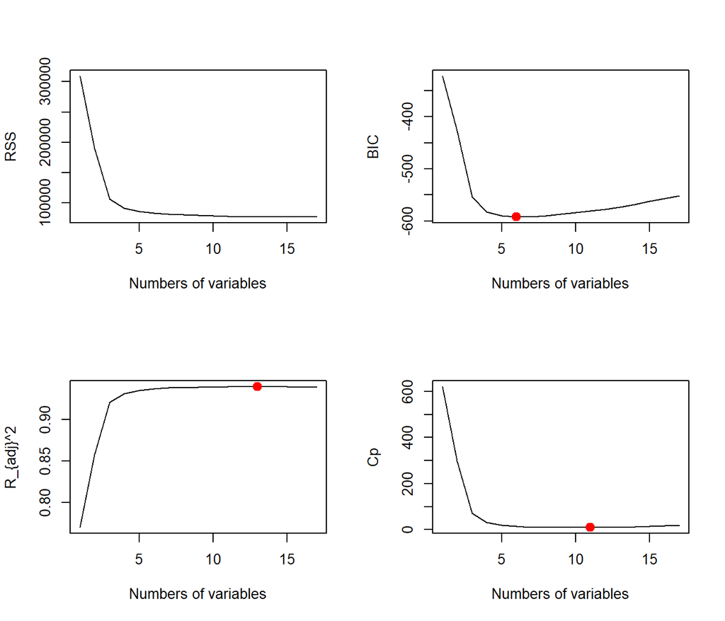

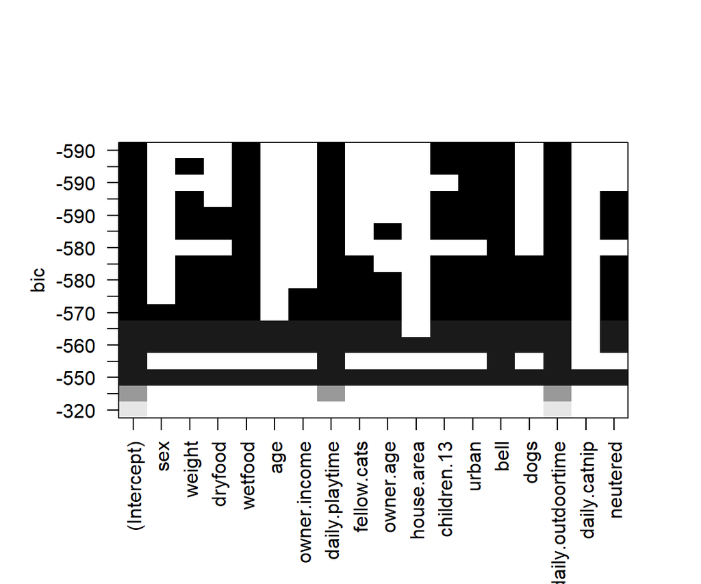

```
##       (Intercept)           wetfood    daily.playtime       children.13
##        106.097330        -10.209847        -10.311803          4.224025
##             urban              bell daily.outdoortime
##        -10.573511        -49.364863          1.142209
```

The above plot illustrates the best subsets ranked based on BIC, where the subset that minimize the BIC is at the top. Thus, the selected variables for the satisfactory model are `wetfood`, `daily.playtime`, `children.13`, `urban`, `bell` and `daily.outdoortime`.

Furthermore, we want to determine the mean square error of the reduced linear regression model based on the selected variables above.

```r
#linear regression using model criterion BIC
kept_predictors <- names(coef(BSS, id = BSS_best_bic))
kept_predictors <- kept_predictors[!kept_predictors %in% "(Intercept)"]
BSS_design_matrix <- model.matrix(birds~., catdat.train)[, kept_predictors]
BSS_data_train <- data.frame(birds = catdat.train$birds, BSS_design_matrix)

LinReg_BIC <- lm(birds~., BSS_data_train)

#make predictions on the test set
BSS_design_matrix_test <- model.matrix(birds~., catdat.test)[, kept_predictors]
BSS_predictions <- predict(LinReg_BIC, newdata = as.data.frame(BSS_design_matrix_test))

#compute test squared errors
BSS_squared_errors <- (catdat.test$birds - BSS_predictions)^2
squared_errors <- data.frame(BSS_squared_errors = BSS_squared_errors)

#the test MSE
MSE_BSS <- mean(BSS_squared_errors)
```

The test mean square error for the reduced model using best subset selection with 6 predictors is `299.88`.

### c) Lasso Regression

Now, we are going to obtain a lasso regression model of the dataset `catdat`.

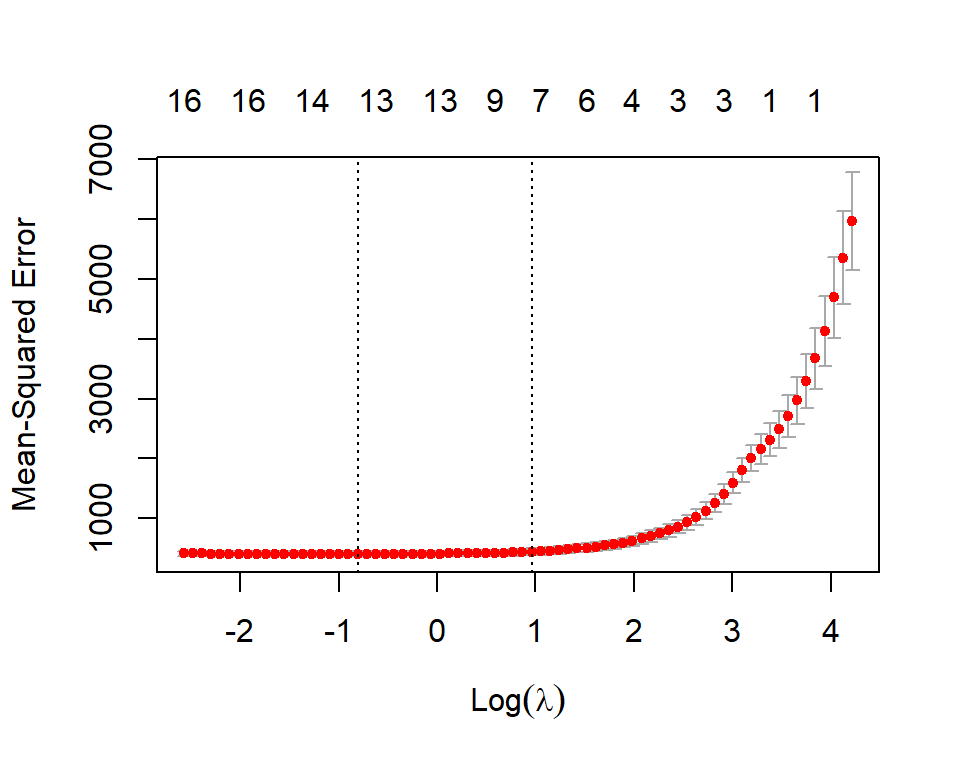

```r
#make matrices of the training and testing data
x.train <- model.matrix(birds~., data = catdat.train)[, -1]
y.train <- catdat.train$birds
x.test <- model.matrix(birds~., data = catdat.test)[,-1]
y.test <- catdat.test$birds

#fits a genelarized linar model with lasso penalty.
lasso_mod <- glmnet(x.train, y.train, alpha = 1)

#k-fold cross validation to choose lambda
set.seed(1)
cv.out = cv.glmnet(x.train, y.train, alpha = 1)
plot(cv.out)
```

```r
bestlam.Lasso<- cv.out$lambda.min

lasso_predictions = predict(lasso_mod, s = bestlam.Lasso, newx= x.test)
lasso_square_errors <- as.numeric((lasso_predictions - y.test)^2)
squared_errors_lasso<- data.frame(lasso_square_errors = lasso_square_errors, squared_errors)

#determine the coefficients used in the lasso regression
lasso.coef = predict(lasso_mod, type = "coefficients", s = bestlam.Lasso)[1:18,]
all_coefs = lasso.coef
nonzero_coefs = all_coefs[all_coefs!=0]

#the test MSE
MSE_lasso <- mean(lasso_square_errors)
```

For this method, $\lambda$ is chosen using cross-validation, where the $\lambda$ that minimizes the mean squared error is selected and was found to be $\lambda =$ `0.4465155`. A beneficial property of the lasso regression is that predictors can be shrunken all the way to zero, meaning that parameters that is not significant for estimating the response can be completely erased from the model. In our case, the non-zero coefficients using lasso regression are `(Intercept), weight, dryfood, wetfood, owner.income, daily.playtime, owner.age, house.area` `children.13, urban, bell, dogs, daily.outdoortime, neutered`and the omitted once are `sex, age, fellow.cats, daily.catnip`.

The test mean square error for the lasso regression model was found to be `298.4227495`.

### d)

For increased values of $\lambda$ the slopes gets smaller and smaller until they reach zero as $\lambda \to \infty$. This means that one is left with a model containing only the intercept. On the other hand, when $\lambda =0$ the lasso regression line will be the same as for the least squared regression line, i.e. the full multiple linear regression model, since the term that provides for penalization vanishes.

### e)

We will now show that the test MSE of the best subset selection model and the lasso regression model indeed are better than the test MSE for the model with only intercept and the full model. We find these test MSE’s the following way

```r
#determine MSE for a model containing only the intercept
ILR <- lm(birds~1, data = catdat.train)
ILR_squared_errors <- (catdat.test$birds - summary(ILR)$coefficients[1])^2
MSE_ILR <- mean(ILR_squared_errors)


#determine MSE for a multiple linear regression
MLR <- lm(birds~., data = catdat.train)
MLR_predictions <- predict(MLR, newdata = catdat.test)
MLR_squared_errors <- (catdat.test$birds - MLR_predictions)^2
MSE_MLR <- mean(MLR_squared_errors)
```

The test mean square errors for respectively the model containing only intercept and the multiple linear regression model were found to be `4914.0693576` and `301.9185792`. Both of these values are greater than the once obtained for best subset selection with BIC as model criteria and lasso regression. Hence, the models from b) and c) results in better predictions than both the full model and the model with no predictors.

### f)

From the previous tasks we found the MSE for the four cases to be

```
##                             the test MSE
## Best Subset Selection           299.8835
## Lasso Regression                298.4227
## Multiple Linear Regression      301.9186
## Intercept Linear Regression    4914.0694
```

Further, all the other MSE’s results in a mean square error on about $300$.

### Problem 2

### a)

1. TRUE
2. TRUE
3. FALSE
4. FALSE

### b)

The basis functions for a cubic spline with knots at the quantiles $q_1$, $q_2$ of a variable $X$ are given as

$$\begin{align}
b_1(X) = & X && b_4(X) =(X-q_1)^3_+ \\
b_2(X) = & X^2 && b_5(X) =(X-q_2)^3_+\\
b_3(X) = & X^3
\end{align}$$

where $b_4$,$b_5$ are truncated power basis functions. These are defined

$$\begin{equation}
(X-q_i)=
\begin{cases}
(X-q_i) & \text{if} X > q_i \\
0 & \text{otherwise}
\end{cases}
\end{equation}$$

### c)

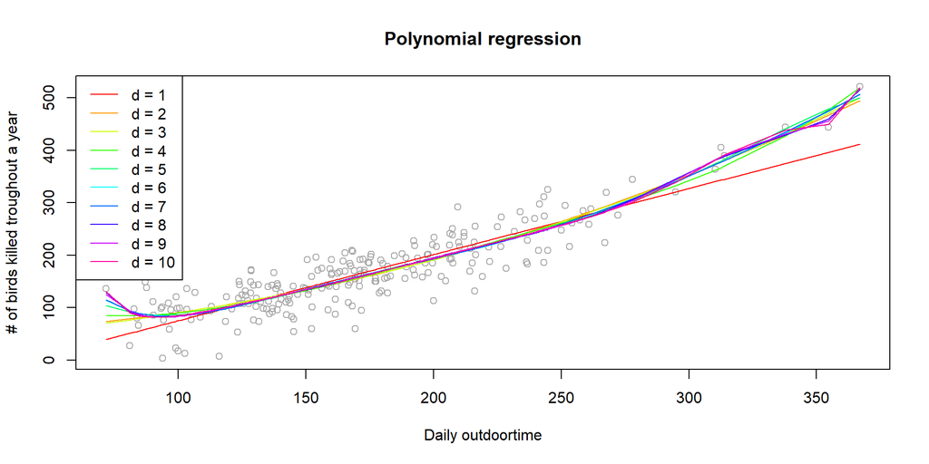

```r
pr.train <- catdat.train[c("daily.outdoortime","birds")]
deg = 1:10

plot(pr.train, col ='darkgrey', main='Polynomial regression',xlab = 'Daily outdoortime',ylab='# of birds killed troughout a year')
co = rainbow(length(deg))


MSE.pr <- rep('numeric',lenght=length(deg))


for (d in deg) {
  mod <- lm(birds ~ poly(daily.outdoortime,d),pr.train)

  lines(cbind(pr.train$daily.outdoortime,mod$fit)[order(pr.train$daily.outdoortime),],col=co[d])

  pred <- predict(mod,pr.train)
  MSE.pr[d] <- mean((pred-pr.train$birds)^2)

}
legend("topleft",legend = paste("d =",deg),lty=1,col=co)
```

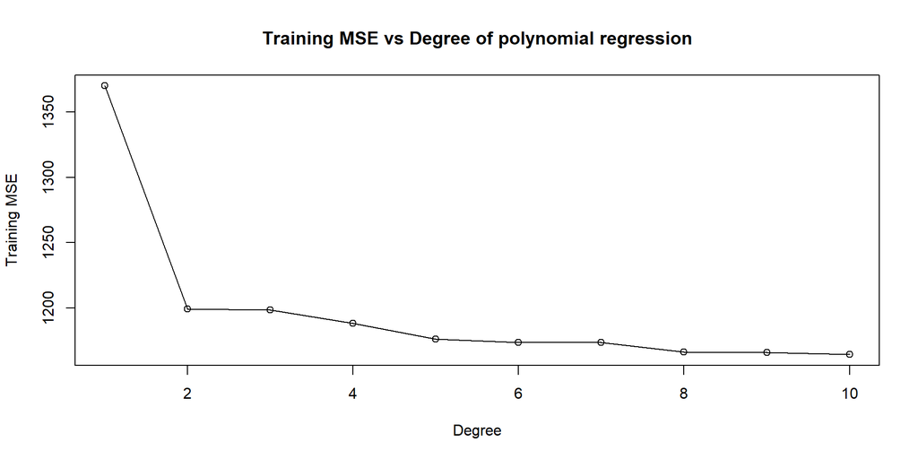

| Degree | Training MSE |
| --- | --- |
| 1 | 1369.99652111442 |
| 2 | 1199.20159566985 |
| 3 | 1198.49876971155 |
| 4 | 1188.22703706041 |
| 5 | 1175.98070849339 |
| 6 | 1173.48472419999 |
| 7 | 1173.43712184647 |
| 8 | 1166.43680120411 |
| 9 | 1166.01882439429 |
| 10 | 1164.36762557602 |

```r
plot(deg,MSE.pr,type="o",xlab="Degree",ylab="Training MSE",main="Training MSE vs Degree of polynomial regression")
```

Both the plot and the table of the training error show a decrease for an increasing number of degrees. There is an especially sharp decrease in the training MSE from $d=1$ to $d=2$. From the figure showing the polynomial regression for different degrees $d =1,2,...,10$, we see that the models with $d>1$ prove a markedly better fit for the training data points in the region `Daily outdoortime` $> 300$. This fits well with the training MSE being decidedly lower for those polynomial fits. From the figure we also can see that the polynomial fits of higher degrees seem to fit the individual data points very well, which might indicate some overfitting for those models. This is especially obvious for $d=10$. However, since we are considering the training MSE, overfitting will lead to a decrease, so these models do have a lower training MSE than those with a lower degree.

### Problem 3

### a)

1. TRUE
2. TRUE
3. FALSE
4. FALSE

### b)

The length of the branches in the tree corresponds to how much the RSS decreases along that branch, i.e. the longer the branch the more reduced RSS get. When we make a regression tree we want the RSS to be as small as possible. Hence, we want to keep the branches which are the longest. This results in that the pruned tree with three leaves will have splits at `age < 81.5` and `country: indonesia, japan, Korea`.

### c)

###### (i)

The simple classification tree yields

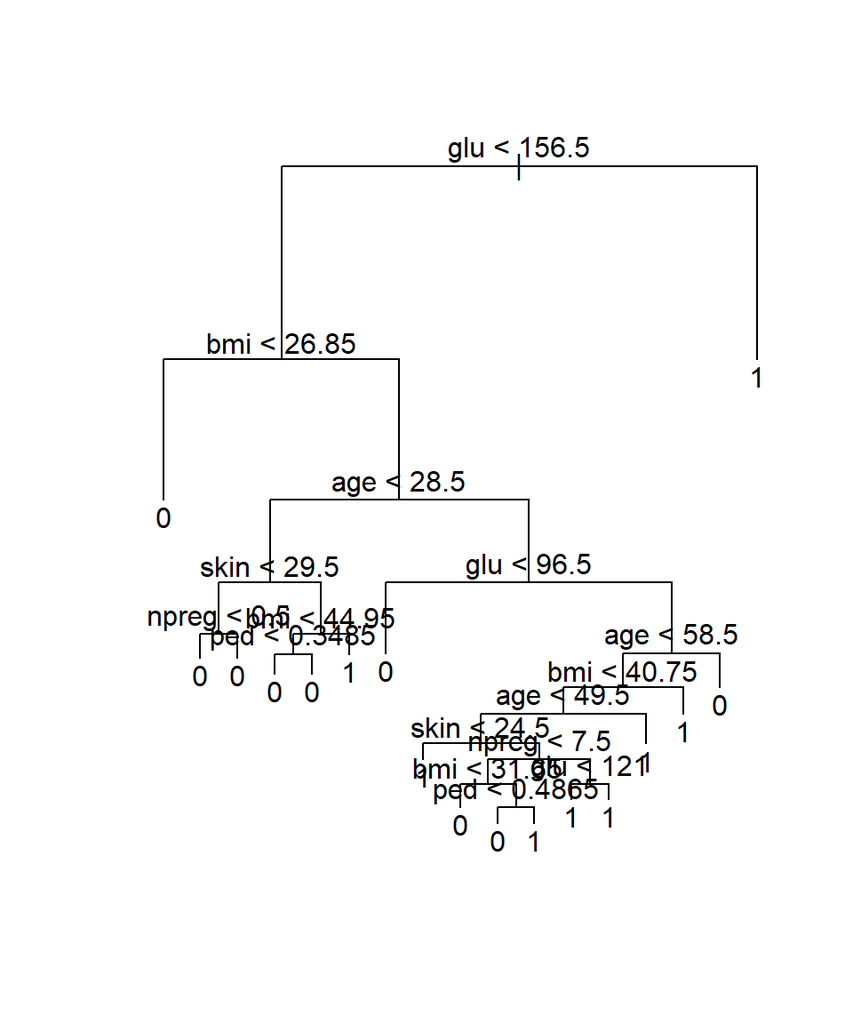

```
##          response.test
## yhat.tree   0   1
##         0 126  28
##         1  29  49
```

The misclassification error on the test set for this simple classification tree is `0.246`.

Furthermore, cost-complexity pruning using 10-fold cross validation was applied on the training dataset resulting in that three leaves would be optimal numbers of leaves for the pruned tree, as shown below.

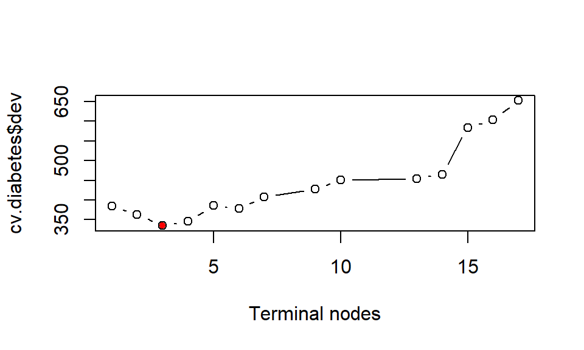

This resulted in the following pruned tree.

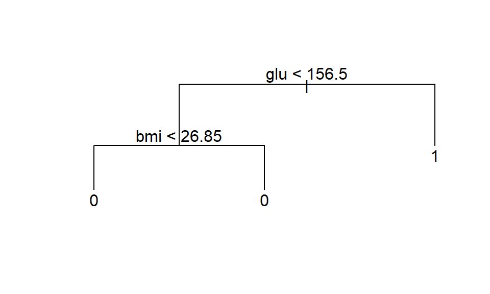

```
##           Truth
## Prediction   0   1
##          0 148  49
##          1   7  28
```

##### (ii)

Now, the classification tree will be constructed using the random forest approach.

```
##        response.test
## yhat.rf   0   1
##       0 133  32
##       1  22  45
```

```
## [1] 0.2327586
```

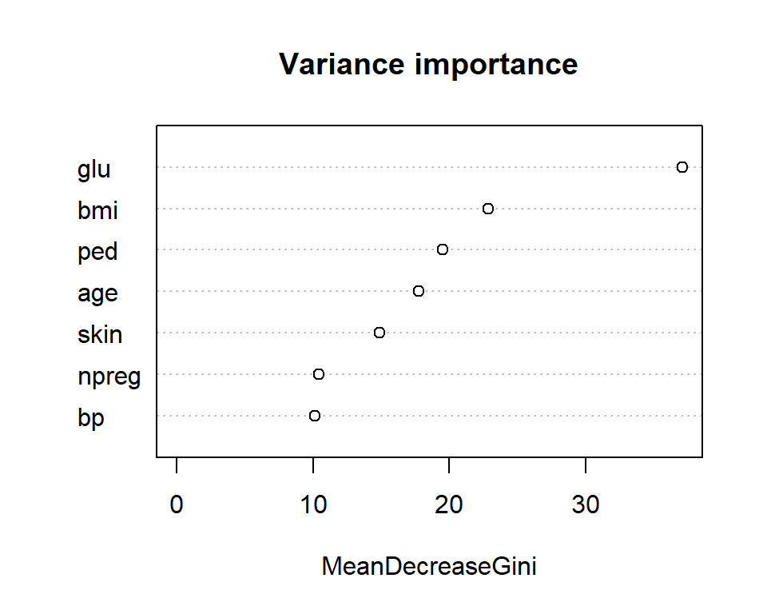

When making this classification tree, the number of variables randomly sampled as candidates at each split `mtry` was chosen to be equal to $\sqrt{p}$, which in our case is $\sqrt{7} \approx 2.646 \approx 3$. Hence, we choose `mtry = 3`. The number of trees `ntree = 500` is not a tuning parameter but is chosen large enough. The misclassification error on the test set when using random forest to train the model (??) was found to be `0.233`.

From the variance importance plot above, we can see that `glu` and `bmi` has the highest `MeanDecreaseGini`. Hence, they are the most influential predictors of diabetes. This corresponds well to the tree we made in 3c) (i) where the two first splits were based on glu and bmi.

# Problem 4

### a)

1. TRUE
2. TRUE
3. FALSE
4. TRUE

### b)

##### (i)

A SVM is a more suitable approach than logistic regression for this dataset since we have p>>1 and therefore always can find a separating hyperplane, excepting exact feature ties.

Another method that could be used instead of a SVM is tree-based classification, since it also allows for a higher number of dimensions than observations. It then would be beneficial to use an ensembel method like random forest to reduce the variance.

##### (ii)

The paper suggests using ensemble learning with SVMs to do feature selection on genomic data through elimation. That is, using bootstrapping multiple SVM models are built and then aggregated to form one final model which is used to eliminate genomic features unimportant for patient classification.

##### (iii)

```r
svm.leukemia.linear <- svm(Category~., data = d.leukemia.train, kernel = "linear", cost = 1, scale = TRUE)

#training error
y.leukemia.train <- predict(svm.leukemia.linear, newdata = d.leukemia.train)
table.leukemia.train <- table(Predicted_train = y.leukemia.train, Truth_train = d.leukemia.train$Category)
table.leukemia.train
```

```
##                Truth_train
## Predicted_train Non-Relapse Relapse
##     Non-Relapse          30       0
##     Relapse               0      15
```

```r
#test error
y.leukemia.test <- predict(svm.leukemia.linear, newdata = d.leukemia.test)
table.leukemia.test <- table(Predicted_test = y.leukemia.test, Truth_test = d.leukemia.test$Category)
table.leukemia.test
```

```
##               Truth_test
## Predicted_test Non-Relapse Relapse
##    Non-Relapse           8       4
##    Relapse               1       2
```

The training misclassification error rate for the support vector classifier with linear kernel using $C=1$ is `0` and the test misclassification error is `0.333`. It is not surprising that the training error rate is equal to zero, since the number of covariates are much bigger then the number of observations. Meaning that we are guaranteed to find a separating hyperplane. This can result in overfitting. (usikker på om vi skal ha med den siste setningen…)

##### (iv)

```r
#C = 1, gamma = 10^-2
svm.leukemia.radial1 <- svm(Category~., data = d.leukemia.train, kernel = "radial", cost = 1, gamma = 10^(-2), scale = TRUE)

#training error
y.leukemia.train1 <- predict(svm.leukemia.radial1, newdata = d.leukemia.train)
table.leukemia.train1 <- table(Predicted_train = y.leukemia.train1, Truth_train = d.leukemia.train$Category)
table.leukemia.train1
```

```
##                Truth_train
## Predicted_train Non-Relapse Relapse
##     Non-Relapse          30       0
##     Relapse               0      15
```

```r
#test error
y.leukemia.test1 <- predict(svm.leukemia.radial1, newdata = d.leukemia.test)
table.leukemia.test1 <- table(Predicted_test = y.leukemia.test1, Truth_test = d.leukemia.test$Category)
table.leukemia.test1
```

```
##               Truth_test
## Predicted_test Non-Relapse Relapse
##    Non-Relapse           9       6
##    Relapse               0       0
```

The training misclassification error rate for the support vector classifier with radial kernel using $C=1$ and $\gamma = 10^{-2}$ is `0` and the test misclassification error rate is `0.4`.

```r
#C = 1, gamma = 10^-5
svm.leukemia.radial2 <- svm(Category~., data = d.leukemia.train, kernel = "radial", cost = 1, gamma = 10^(-5), scale = TRUE)

#training error
y.leukemia.train2 <- predict(svm.leukemia.radial2, newdata = d.leukemia.train)
table.leukemia.train2 <- table(Predicted_train = y.leukemia.train2, Truth_train = d.leukemia.train$Category)
table.leukemia.train2
```

```
##                Truth_train
## Predicted_train Non-Relapse Relapse
##     Non-Relapse          30      15
##     Relapse               0       0
```

```r
#test error
y.leukemia.test2 <- predict(svm.leukemia.radial2, newdata = d.leukemia.test)
table.leukemia.test2 <- table(Predicted_test = y.leukemia.test2, Truth_test = d.leukemia.test$Category)
table.leukemia.test2
```

```
##               Truth_test
## Predicted_test Non-Relapse Relapse
##    Non-Relapse           9       6
##    Relapse               0       0
```

For the support vector classifier with radial kernal using $C = 1$ and $\gamma = 10^{-5}$, the training misclassification error rate is `0.333` and the test misclassification error rate is `0.4`.

### c)

The polynomial kernel for the feature space with inputs $X_1$ and $X_2$ and degree $d=2$ is
$$\begin{align*}
K(\boldsymbol{x}_i, \boldsymbol{x}_{i'}) &=(1+\sum_{j=1}^2x_{ij}x_{i'j})^2 = (1 + x_{i1}x_{i'1} + x_{i2}x_{i'2})^2 \\
&= 1 + 2x_{i1}x_{i'1} + 2x_{i2}x_{i'2} + (x_{i1}x_{i'1})^2 + 2x_{i1}x_{i'1}x_{i2}x_{i'2} + (x_{i2}x_{i'2})^2.
\end{align*}$$
This can be written as
$$\begin{align*}
K(\boldsymbol{x}_i, \boldsymbol{x}_{i'}) &= h_1(x)h_1(x') + h_2(x)h_2(x') + h_3(x)h_3(x') + h_4(x)h_4(x') + h_5(x)h_5(x') + h_6(x)h_6(x') \\
&= \sum_{j=1}^6 h_j(x)h_j(x') = \langle h(x),h(x') \rangle,
\end{align*}$$

where
$$\begin{align*}
h_1(x)h_1(x') &= 1 \implies h_1(x) = 1 \\
h_2(x)h_2(x') &= 2x_{i1}x_{i'1} \implies h_2(x) = \sqrt{2}x_{i1}\\
h_3(x)h_3(x') &= 2x_{i2}x_{i'2} \implies h_3(x) = \sqrt{2}x_{i2}\\
h_4(x)h_4(x') &= x_{i1}^2x_{i'1}^2 \implies h_4(x) = x_{i1}^2\\
h_5(x)h_5(x') &= 2x_{i1}x_{i2}x_{i'1}x_{i'2} \implies h_5(x) = \sqrt{2}x_{i1}x_{i2}\\
h_6(x)h_6(x') &= x_{i2}^2x_{i'2}^2 \implies h_6(x) = x_{i2}^2.
\end{align*}$$

# Problem 5

### a)

1. TRUE
2. FALSE
3. FALSE
4. FALSE

### b)

##### (i)

First, we randomly assign a cluster to each observation and obtain the following plot.

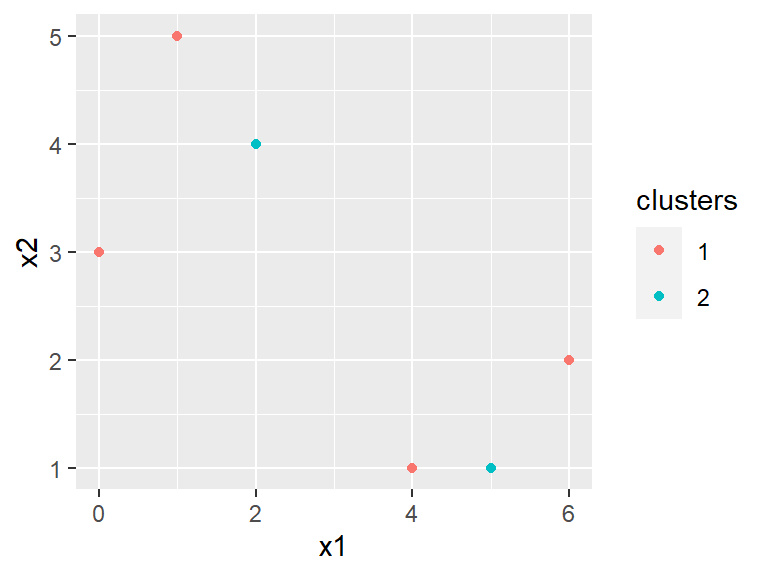

##### (ii)

Secondly, we calculate the centroids for each cluster and add them to the plot.

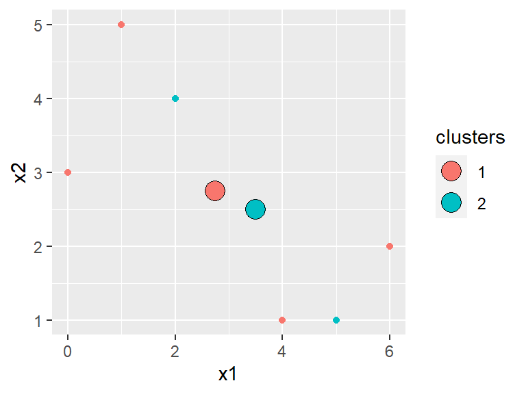

##### (iii)

Lastly, we assign the observations new clusters based on which centroid is closest in euclidain distance and obtain the following plot.

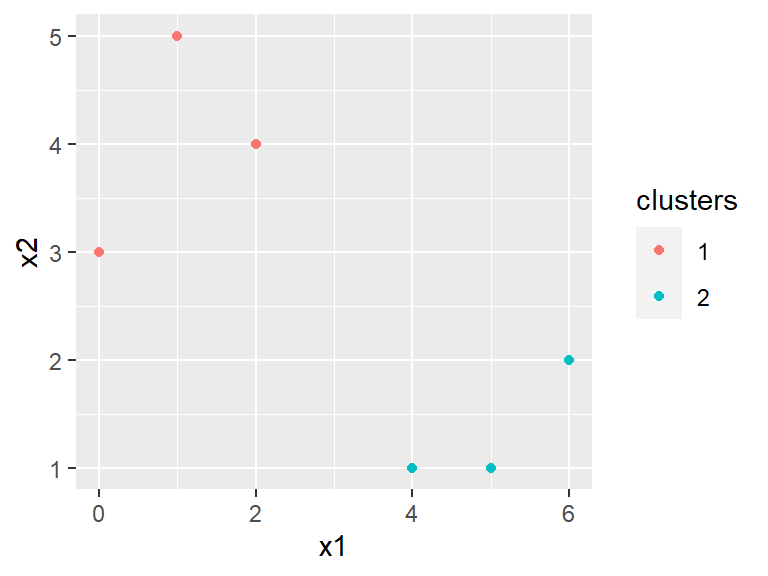

### c)

The following code shows how hierarchical clustering with complete, single and average linkage was implemented both using Euclidean distance and correlation-based distance.

```r
#hierarchical clustering Euclidean distance
CE_hclust = hclust(dist(GeneData), method = "complete")
SE_hclust = hclust(dist(GeneData), method = "single")
AE_hclust = hclust(dist(GeneData), method = "average")

#hierarchical clustering using correlation-based distance
correlation_dist = as.dist(1-cor(t(GeneData)))
CC_hclust = hclust(correlation_dist, method = "complete")
SC_hclust = hclust(correlation_dist, method = "single")
AC_hclust = hclust(correlation_dist, method = "average")
```

The following plot shows dendrograms for the investigated choices for linkage and distance.

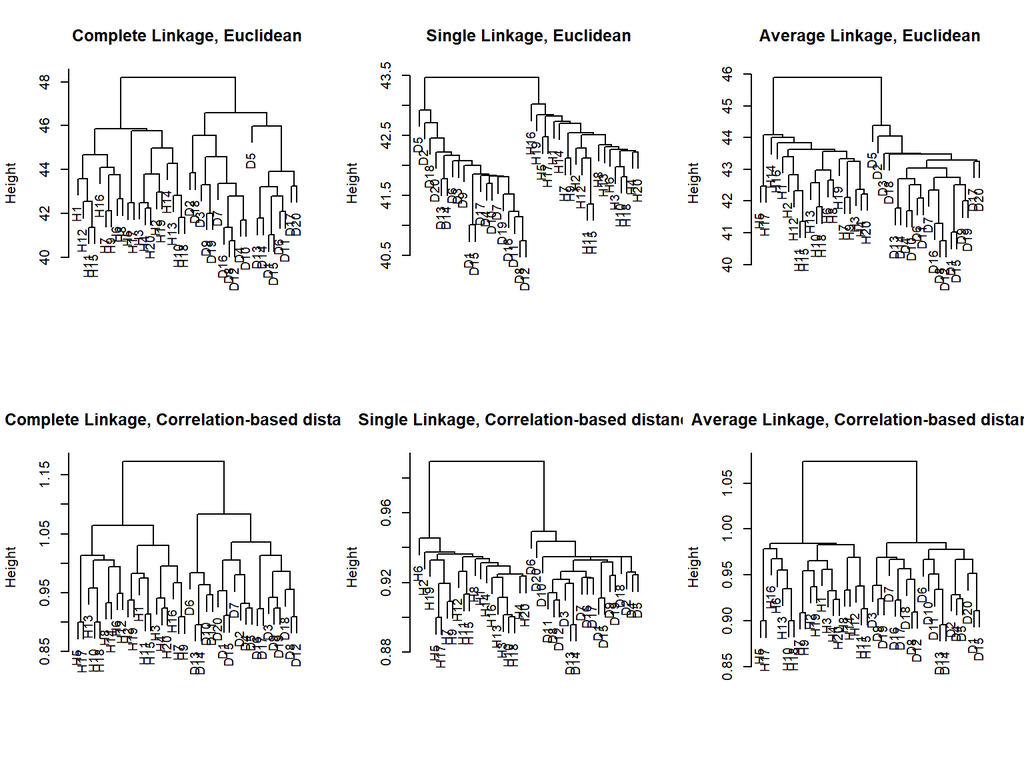

#### d)

Based on the dendrograms from c), the tissues were clustered into two groups the following way.

```r
#cut the clusters in two groups
CE_2groups =  cutree(CE_hclust, 2)
SE_2groups =  cutree(SE_hclust, 2)
AE_2groups =  cutree(AE_hclust, 2)
CC_2groups = cutree(CC_hclust, 2)
SC_2groups = cutree(SC_hclust, 2)
AC_2groups = cutree(AC_hclust, 2)
```

For all the six combinations of linkages and distance measures, the tissues were clustered into groups that coincide with whether the tissues came from a healthy patient group or the tissues came from a diseased patient group (muligens litt rar setning). Hence, all the hierarchical clustering methods performed equally good and there is no hierarchical clustering method that stands out as the best.

### e)

##### (i)

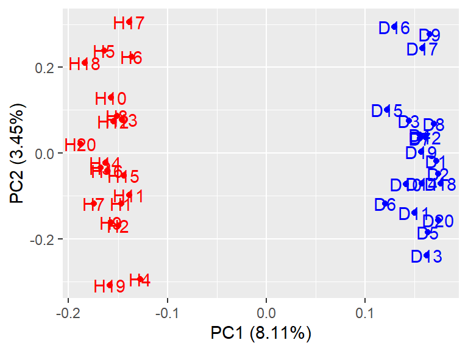

##### (ii)

The first 5 PCs explain 21.1% of the variance.

### f)

From the plot of the two first principal components, we see that the groups differ a lot along the first principal component.To find the genes that vary the most across the two groups we can therefore look at the genes that contribute the most to the first principal component.

The five genes that have the highest variance across the two groups are thus

```
##       G502       G589       G565       G590       G600
## 0.09485044 0.09449766 0.09183823 0.09173169 0.09167322
```